# 2.6 Practical: logistic regression

Benjamin Rosenbaum

October 20, 2020

# Statistical model

Suppose we want to measure the effect of a continuous variable on presence / absence data.

E.g. presence of a species in different locations: $y\in[0,1]$ presence (=1) or absence (=0), $x$ = temperature in location.

Statistical model:
$$\begin{aligned}
y_i & \sim \text{bernoulli}(p_i) \\
\text{logit}(p_i) &= a+b\cdot x_i \\
\text {or, equivalently:}\quad p_i &= \text{inv.logit}(a+b\cdot x_i)
\end{aligned}$$
$p_i$ is the probability of presence of the species, the distribution of $y_i$ is bernoulli (coin-flip).

We assume a linear relationship of $\text{logit}(p)$ with temperature. (Realistically, a hump-shaped relationship would make more sense.)

$\text{inv.logit}()$ transforms the values of the whole axis to the interval (0,1)

Research question: is there a positive effect of the predictor to the presence of the species?

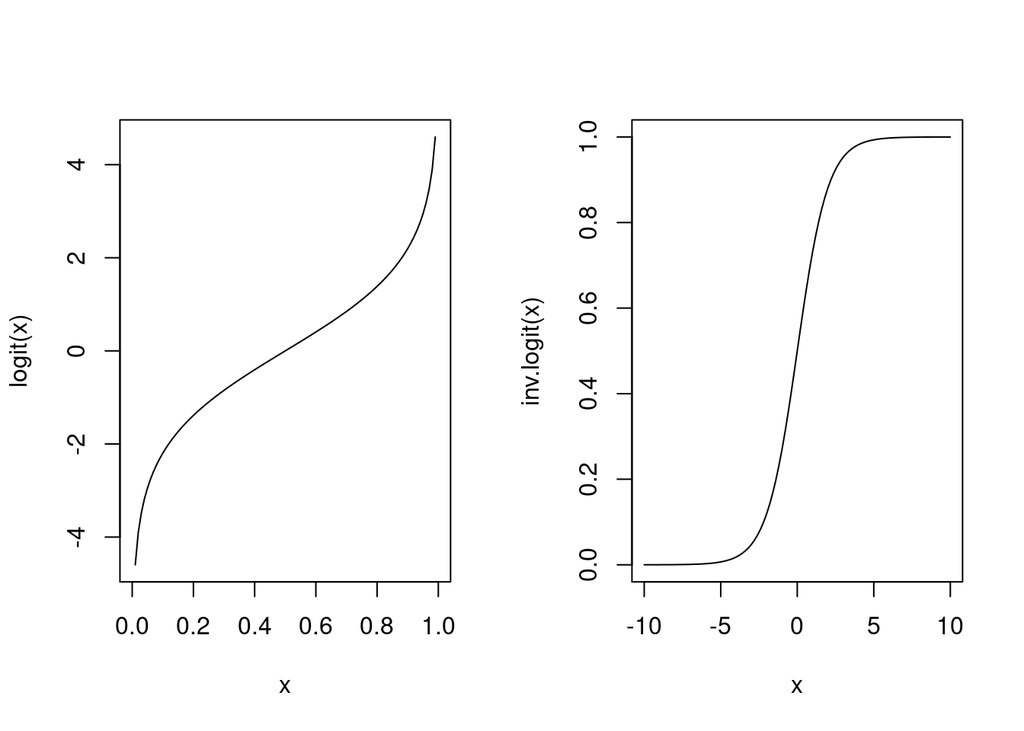

```r
library(boot)
par(mfrow=c(1,2))
curve(logit, from=0, to=1)
curve(inv.logit, from=-10, to=10)
```

Research question: is there a positive effect of the predictor to the presence of the species?

# Setup

```r
rm(list=ls())
library(rstan)
library(coda)
```

```r
library(BayesianTools)
library(boot)
setwd("~/Nextcloud/teaching Bayes")

rstan_options(auto_write = TRUE)
options(mc.cores = 3)
```

# Generate data

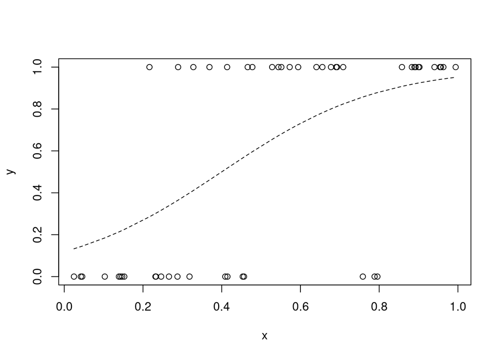

```r
set.seed(123) # initiate random number generator for reproducibility
n = 50
x = sort(runif(n, 0, 1))

a = -2
b = 5

p = inv.logit(a+b*x)

y = rbinom(n=n, size=1, prob=p)

plot(x,y)
lines(x,p, lty=2)
```

# Stan code and fitting

```r
data = list(n=n,
            x=x,
            y=y)

stan_code = '
data {
  int  n;
  real x[n];
  int  y[n];
}
parameters {
  real a;
  real b;
}
model {
  real p[n];
  // priors
  a ~ normal(0, 10);
  b ~ normal(0, 10);
  // likelihood
  for(i in 1:n){
    p[i] = inv_logit(a+b*x[i]);
    y[i] ~ bernoulli(p[i]);
  }
}
'
```

```r
stan_model = stan_model(model_code=stan_code)
# save(stan_model, file="stan_model.RData")
# load("stan_model.RData")
```

```r
fit  = sampling(stan_model,
                data=data,
                chains=3,
                iter=2000,
                warmup=1000
)

print(fit, digits=3, probs=c(0.025, 0.975))
```

```
## Inference for Stan model: e2c3ac8b54078b9a76e5017b8d33efbd.
## 3 chains, each with iter=2000; warmup=1000; thin=1;
## post-warmup draws per chain=1000, total post-warmup draws=3000.
##
##         mean se_mean    sd    2.5%   97.5% n_eff  Rhat
## a     -2.765   0.034 0.796  -4.477  -1.339   551 1.003
## b      6.454   0.065 1.581   3.601   9.799   585 1.002
## lp__ -23.915   0.033 0.965 -26.604 -22.982   857 1.001
##
## Samples were drawn using NUTS(diag_e) at Wed Oct 14 10:45:59 2020.
## For each parameter, n_eff is a crude measure of effective sample size,
## and Rhat is the potential scale reduction factor on split chains (at
## convergence, Rhat=1).
```

```
## ci_level: 0.8 (80% intervals)
```

```
## outer_level: 0.95 (95% intervals)
```

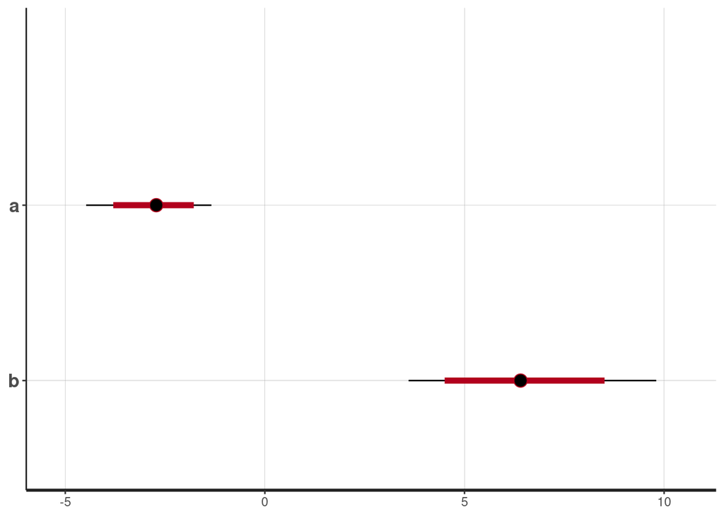

```r
plot(fit)
```

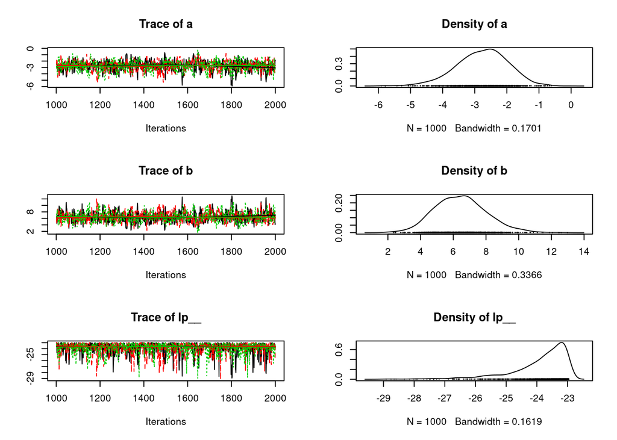

```r
plot(As.mcmc.list(fit)) # from coda package
```

```r
posterior=as.matrix(fit)

head(posterior)
```

```
##           parameters
## iterations         a        b      lp__
##       [1,] -2.479585 6.492597 -23.35352
##       [2,] -2.503266 5.999644 -22.97177
##       [3,] -2.348664 4.375703 -24.71010
##       [4,] -2.490399 4.623405 -24.63987
##       [5,] -2.515632 5.491616 -23.11432
##       [6,] -3.067657 6.917060 -23.16606
```

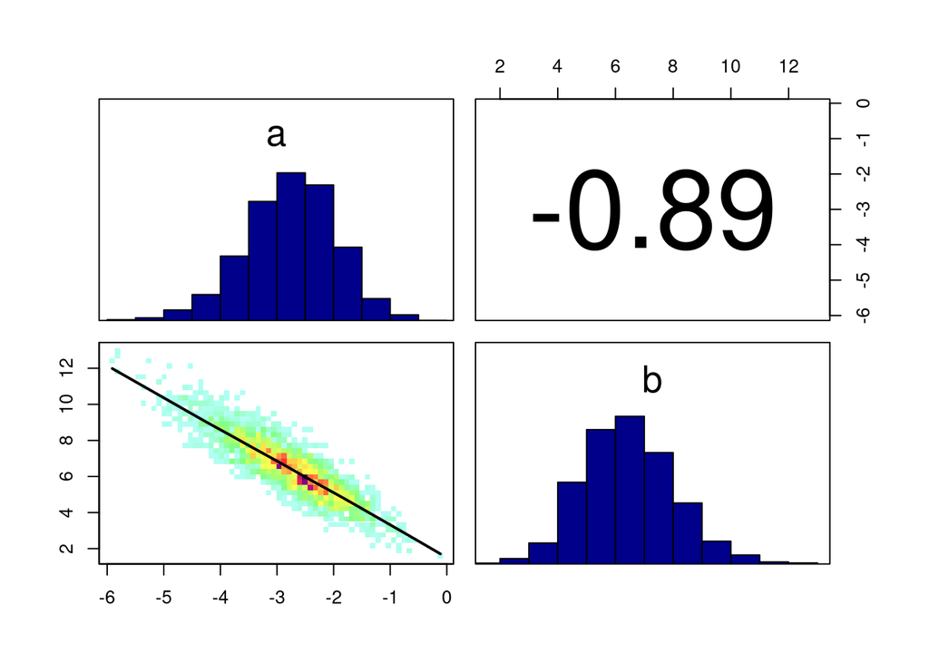

```r
correlationPlot(posterior[, 1:2], thin=1)
```

# Predictions

First, we generate credible intervals for the deterministic model (for p). (90%, but choose as you like)

Later, we generate prediction intervals for the data (for y) using also the stochastic part.

```r
x.pred = seq(from=0, to=1, by=0.01)
p.pred = matrix(0, nrow=nrow(posterior), ncol=length(x.pred))

for(i in 1:nrow(posterior)){
  p.pred[i, ] = inv.logit(posterior[i,"a"] + posterior[i,"b"]*x.pred)
}
```

Example: First 100 realizations from the posterior

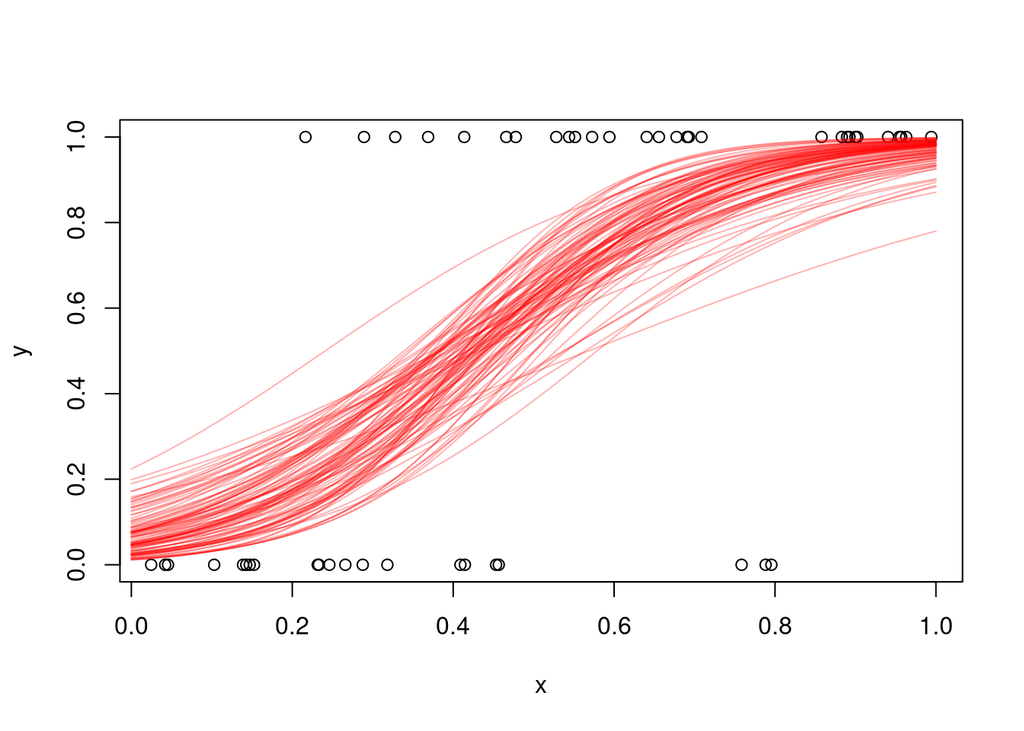

```r
plot(x,y)
for(i in 1:100){
  lines(x.pred, p.pred[i, ], col=adjustcolor("red", alpha.f=0.3))
}
```

Now, the credible intervals using the whole distribution

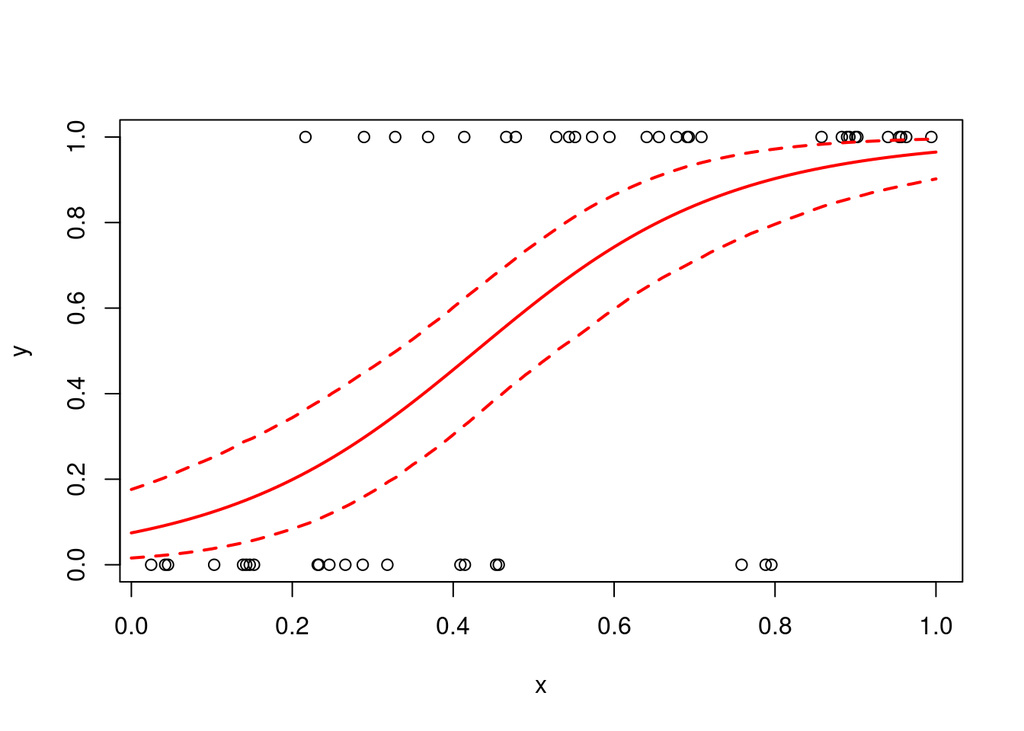

```r
plot(x,y)

p.pred.mean = apply(p.pred, 2, function(x) mean(x))
lines(x.pred, p.pred.mean, col="red", lwd=2)

p.pred.q05 = apply(p.pred, 2, function(x) quantile(x, probs=0.05))
lines(x.pred, p.pred.q05, col="red", lwd=2, lty=2)

p.pred.q95 = apply(p.pred, 2, function(x) quantile(x, probs=0.95))
lines(x.pred, p.pred.q95, col="red", lwd=2, lty=2)
```

Now, we draw predicted data from the bernoulli (=binomial(1)) distribution in the statistical model.

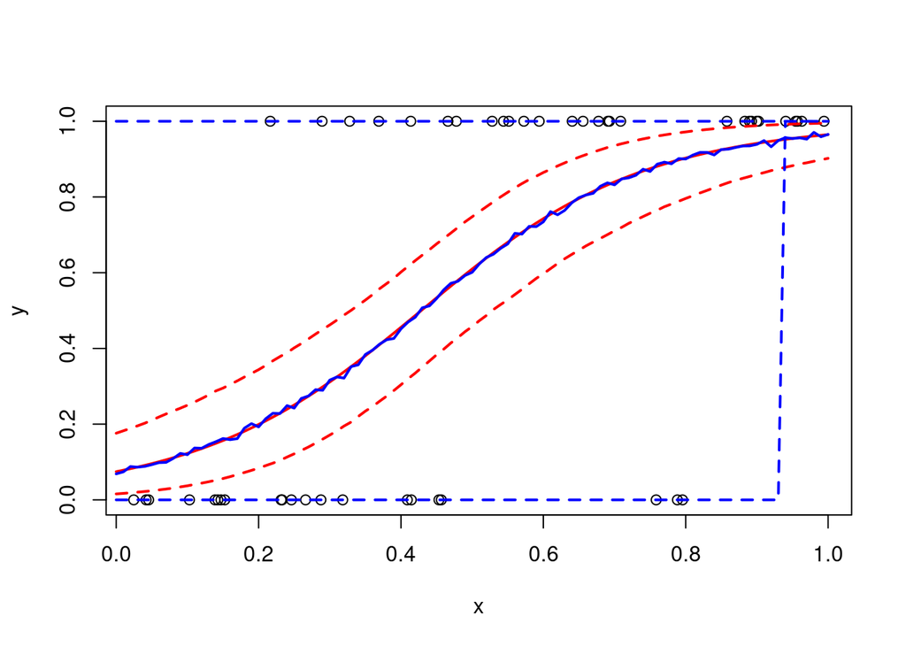

```r
y.pred = matrix(0, nrow=nrow(posterior), ncol=length(x.pred))
for(i in 1:nrow(posterior)){
  y.pred[i, ] = rbinom(n=length(x.pred), size=1, p=inv.logit(posterior[i,"a"] + posterior[i,"b"]*x.pred))
}

plot(x,y)
lines(x.pred, p.pred.mean, col="red", lwd=2)
lines(x.pred, p.pred.q05, col="red", lwd=2, lty=2)
lines(x.pred, p.pred.q95, col="red", lwd=2, lty=2)

y.pred.mean = apply(y.pred, 2, function(x) mean(x))
lines(x.pred, y.pred.mean, col="blue", lwd=2)

y.pred.q05 = apply(y.pred, 2, function(x) quantile(x, probs=0.05))
lines(x.pred, y.pred.q05, col="blue", lwd=2, lty=2)

y.pred.q95 = apply(y.pred, 2, function(x) quantile(x, probs=0.95))
lines(x.pred, y.pred.q95, col="blue", lwd=2, lty=2)
```

# Vectorized stan code

Same as above, just coded more efficiently without a for loop

```r
stan_code_2 = '
data {
  int n;
  vector[n] x;
  int y[n];
}
parameters {
  real a;
  real b;
}
model {
  // priors
  a ~ normal(0, 10);
  b ~ normal(0, 10);
  // likelihood
  y ~ bernoulli(inv_logit(a+b*x));
}
'

stan_model_2 = stan_model(model_code=stan_code_2)
# save(stan_model_2, file="stan_model_2.RData")
# load("stan_model_2.RData")

fit_2  = sampling(stan_model_2,
                  data=data,
                  chains=3,
                  iter=2000,
                  warmup=1000
)
```

```r
print(fit_2)
```

```
## Inference for Stan model: 61aa92e5dbc8262eca972165ec389c1d.
## 3 chains, each with iter=2000; warmup=1000; thin=1;
## post-warmup draws per chain=1000, total post-warmup draws=3000.
##
##        mean se_mean   sd   2.5%    25%    50%    75%  97.5% n_eff Rhat
## a     -2.68    0.03 0.82  -4.40  -3.19  -2.64  -2.11  -1.20   600 1.01
## b      6.33    0.07 1.64   3.41   5.17   6.25   7.38   9.87   637 1.01
## lp__ -23.98    0.03 1.04 -26.78 -24.38 -23.67 -23.27 -22.98   986 1.00
##
## Samples were drawn using NUTS(diag_e) at Wed Oct 14 10:46:38 2020.
## For each parameter, n_eff is a crude measure of effective sample size,
## and Rhat is the potential scale reduction factor on split chains (at
## convergence, Rhat=1).
```

# Frequentist solution

```r
summary(glm(y~x, family=binomial(link="logit")))
```

```
##
## Call:
## glm(formula = y ~ x, family = binomial(link = "logit"))
##
## Deviance Residuals:
##     Min       1Q   Median       3Q      Max
## -2.1617  -0.6896   0.2881   0.6902   1.7533
##
## Coefficients:
##             Estimate Std. Error z value Pr(>|z|)
## (Intercept)  -2.6140     0.8367  -3.124 0.001783 **
## x             6.0955     1.6675   3.656 0.000257 ***
## ---
## Signif. codes:  0 '***' 0.001 '**' 0.01 '*' 0.05 '.' 0.1 ' ' 1
##
## (Dispersion parameter for binomial family taken to be 1)
##
##     Null deviance: 68.029  on 49  degrees of freedom
## Residual deviance: 45.484  on 48  degrees of freedom
## AIC: 49.484
##
## Number of Fisher Scoring iterations: 5
```